# Module 50

#### Contrast SVE:

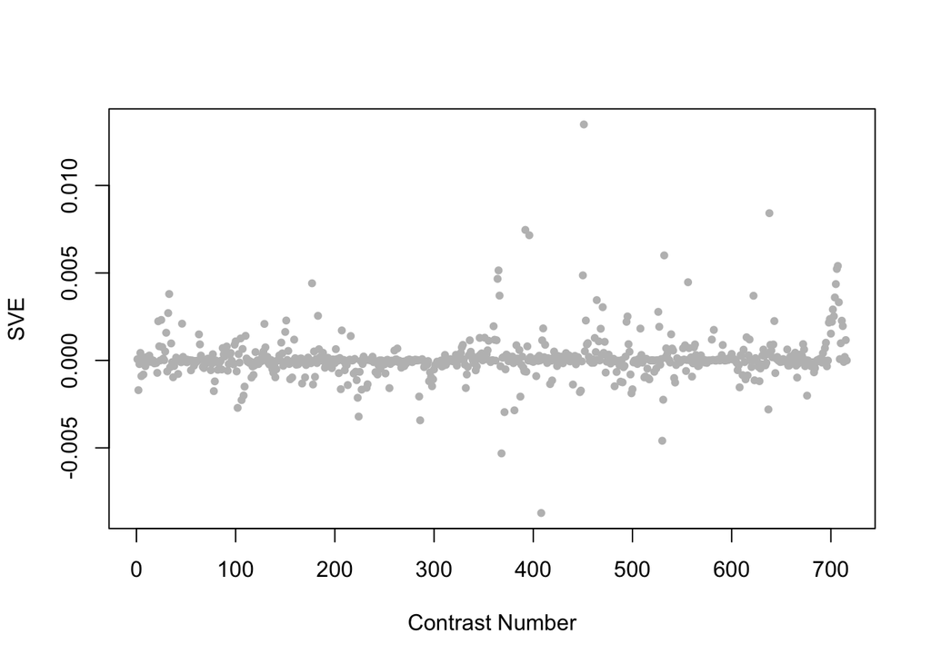

Positive SVE Contrasts:

|  | Contrast.Num | SVE | GEO.GSE | Cond.1 | Cond.2 | Mutation |
| --- | --- | --- | --- | --- | --- | --- |
| GSE25633.s1t1.vs.s3t1 | 451 | 0.01 | GSE25633 | WT#1 | daf-12#1 | daf-12 |
| GSE18132.s2t1.vs.s0t1 | 638 | 0.01 | GSE18132 | Oga starved L1, biological replicate 1 | WT Starved L1, biological rep1 | oga-1 |
| GSE32339.s1t2.vs.s0t2 | 392 | 0.01 | GSE32339 | Adult Mutant, biological rep1 | Adult Wild-type, biological rep1 | nep-1 |
| GSE32031.s1t1.vs.s0t1 | 396 | 0.01 | GSE32031 | Exerimental (nhr-23 RNAi), biological rep1 | Control, biological rep1 | nhr-23 |
| GSE2180.s4t9.vs.s3t9 | 532 | 0.01 | GSE2180 | pp143-1 | p143-2 | pal-1(RNAi) |

Negative SVE Contrasts:

|  | Contrast.Num | SVE | GEO.GSE | Cond.1 | Cond.2 | Mutation |
| --- | --- | --- | --- | --- | --- | --- |
| GSE30505.s1t1.vs.s2t1 | 408 | -0.01 | GSE30505 | L3 N2 (WT) E.V. #1 | L3 N2 (WT) ash-2 #1 | ash-2 |
| GSE35360A.s2t1.vs.s0t1 | 368 | -0.01 | GSE35360 | HF 11d_2.0_rep1 | HF 11d control_rep1 |  |
| GSE2180.s3t9.vs.s2t9 | 530 | -0.00 | GSE2180 | p143-2 | ms143-2 |  |
| GSE41366C.s1t1.vs.s0t1 | 286 | -0.00 | GSE41366 | low_DDVP-continuous_expose-2h_harvest-rep1 | control-continuous_expose-0h_harvest-rep2 |  |
| GSE42592A.s1t3.vs.s1t2 | 224 | -0.00 | GSE42592 | acrylamide_low_expose-8h_rep1 | acrylamide_low_expose-4h_rep1 |  |

$~$

#### Contrast SVE, Up-Regulated Genes Only:

Calculating SVE for up-regulated and down-regulated genes separately may be more informative in many cases than projecting the up- and down- gene sets together. This is due to the fact that the weight distribution of many modules is highly skewed, indicating that only one of the hemi-modules may be biologically meaningful (i.e., a set of genes are strongly correlated by only a few genes (or none) are strongly anti-correlated to that set.)

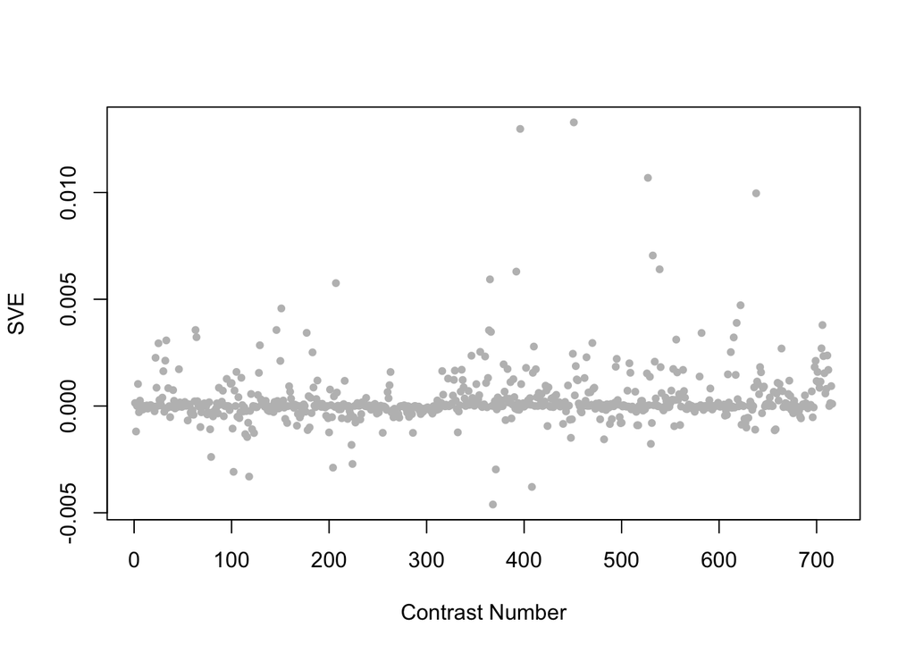

Positive SVE Contrasts:

|  | Contrast.Num | SVE | GEO.GSE | Cond.1 | Cond.2 | Mutation |
| --- | --- | --- | --- | --- | --- | --- |
| GSE25633.s1t1.vs.s3t1 | 451 | 0.01 | GSE25633 | WT#1 | daf-12#1 | daf-12 |
| GSE32031.s1t1.vs.s0t1 | 396 | 0.01 | GSE32031 | Exerimental (nhr-23 RNAi), biological rep1 | Control, biological rep1 | nhr-23 |
| GSE2180.s2t9.vs.s1t9 | 527 | 0.01 | GSE2180 | ms143-2 | 143L | mex-3(zu155);skn-1(RNAi) |
| GSE18132.s2t1.vs.s0t1 | 638 | 0.01 | GSE18132 | Oga starved L1, biological replicate 1 | WT Starved L1, biological rep1 | oga-1 |
| GSE2180.s4t9.vs.s3t9 | 532 | 0.01 | GSE2180 | pp143-1 | p143-2 | pal-1(RNAi) |

Negative SVE Contrasts:

|  | Contrast.Num | SVE | GEO.GSE | Cond.1 | Cond.2 | Mutation |
| --- | --- | --- | --- | --- | --- | --- |
| GSE35360A.s2t1.vs.s0t1 | 368 | -0.00 | GSE35360 | HF 11d_2.0_rep1 | HF 11d control_rep1 |  |
| GSE30505.s1t1.vs.s2t1 | 408 | -0.00 | GSE30505 | L3 N2 (WT) E.V. #1 | L3 N2 (WT) ash-2 #1 | ash-2 |
| GSE54024.s2t1.vs.s6t1 | 118 | -0.00 | GSE54024 | Wild type young adults treated with 0.1mM paraquat, biological rep 1 | isp-1(qm150) ced-4(n1162) double mutant young adults, biological rep 1 |  |
| GSE5793.s2t2.vs.s2t1 | 102 | -0.00 | GSE5793 | Celegans_OP50_8hours_RepA | Celegans_OP50_4hours_RepA |  |
| GSE35360C.s1t1.vs.s0t1 | 371 | -0.00 | GSE35360 | HFHQ 3d_0.2_rep1 | HFHQ 3d control_rep1 |  |

$~$

#### Contrast SVE, Down-Regulated Genes Only:

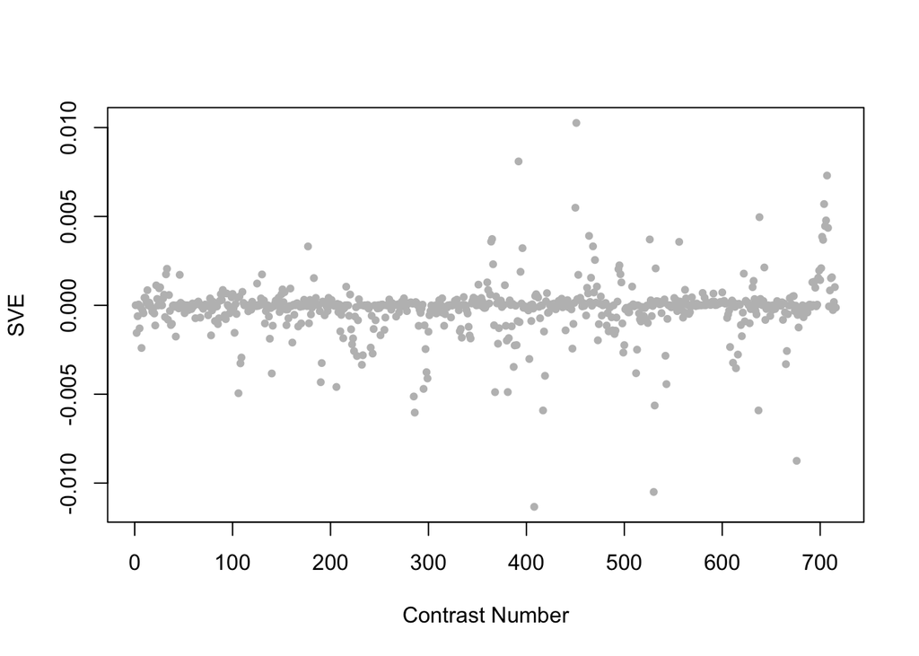

Positive SVE Contrasts:

|  | Contrast.Num | SVE | GEO.GSE | Cond.1 | Cond.2 | Mutation |
| --- | --- | --- | --- | --- | --- | --- |
| GSE25633.s1t1.vs.s3t1 | 451 | 0.01 | GSE25633 | WT#1 | daf-12#1 | daf-12 |
| GSE32339.s1t2.vs.s0t2 | 392 | 0.01 | GSE32339 | Adult Mutant, biological rep1 | Adult Wild-type, biological rep1 | nep-1 |
| GSE11055.s1t7.vs.s1t1 | 707 | 0.01 | GSE11055 | L1-L2 larvae 15 hr after hatching in the presence of food | embryo 2 hr before hatching |  |
| GSE11055.s1t6.vs.s1t1 | 704 | 0.01 | GSE11055 | L1 larvae 12 hr after hatching in the presence of food | embryo 2 hr before hatching |  |
| GSE25633.s2t1.vs.s3t1 | 450 | 0.01 | GSE25633 | daf-19,daf-12#1 | daf-12#1 | daf-19 |

Negative SVE Contrasts:

|  | Contrast.Num | SVE | GEO.GSE | Cond.1 | Cond.2 | Mutation |
| --- | --- | --- | --- | --- | --- | --- |
| GSE30505.s1t1.vs.s2t1 | 408 | -0.01 | GSE30505 | L3 N2 (WT) E.V. #1 | L3 N2 (WT) ash-2 #1 | ash-2 |
| GSE2180.s3t9.vs.s2t9 | 530 | -0.01 | GSE2180 | p143-2 | ms143-2 |  |
| GSE13258.s3t1.vs.s0t1 | 676 | -0.01 | GSE13258 | lin-35 mutant, biological rep 1 | wild-type, biological rep 1 | lin-35 |
| GSE41366C.s1t1.vs.s0t1 | 286 | -0.01 | GSE41366 | low_DDVP-continuous_expose-2h_harvest-rep1 | control-continuous_expose-0h_harvest-rep2 |  |
| GSE28856.s0t2.vs.s0t1 | 417 | -0.01 | GSE28856 | Wild-type 1 h after shifting temperature rep1 | Wild-type 0 h after shifting temperature rep1 |  |

$~$

$~$

#### GO Term Enrichment:

This analysis tests each hemi-module for enrichment of specific GO terms. Only gene-level annotations (e.g., as would be found on the gene’s page in Wormbase) are tested - the hierarchical structure of the GO ontology is not taken into account.

*Note: At least the top two most enriched terms from each GO domain (BP/MF/CC) are shown, even when not statistically significant.*

##### Enriched GO terms: Hemi-module A

| ID | GO.Term | GO Domain | Raw p-value | Adj p-value |
| --- | --- | --- | --- | --- |
| [GO_0006515](http://amigo.geneontology.org/amigo/term/GO:0006515) | protein quality control for misfolded or incompletely synthesized proteins | BP | 1.72e-03 | 9.98e-01 |
| [GO_0006516](http://amigo.geneontology.org/amigo/term/GO:0006516) | glycoprotein catabolic process | BP | 2.00e-03 | 9.98e-01 |
| [GO_0000224](http://amigo.geneontology.org/amigo/term/GO:0000224) | peptide-N4-(N-acetyl-beta-glucosaminyl)asparagine amidase activity | MF | 1.00e-03 | 1.00e+00 |
| [GO_0001888](http://amigo.geneontology.org/amigo/term/GO:0001888) | glucuronyl-galactosyl-proteoglycan 4-alpha-N-acetylglucosaminyltransferase activity | MF | 4.82e-03 | 1.00e+00 |
| [GO_0016012](http://amigo.geneontology.org/amigo/term/GO:0016012) | sarcoglycan complex | CC | 1.44e-02 | 9.99e-01 |
| [GO_0005886](http://amigo.geneontology.org/amigo/term/GO:0005886) | plasma membrane | CC | 2.31e-02 | 9.99e-01 |

##### Enriched GO terms: Hemi-module B

| ID | GO.Term | GO Domain | Raw p-value | Adj p-value |
| --- | --- | --- | --- | --- |
| [GO_0050832](http://amigo.geneontology.org/amigo/term/GO:0050832) | defense response to fungus | BP | 1.60e-03 | 1.00e+00 |
| [GO_0007165](http://amigo.geneontology.org/amigo/term/GO:0007165) | signal transduction | BP | 1.73e-03 | 1.00e+00 |
| [GO_0004061](http://amigo.geneontology.org/amigo/term/GO:0004061) | arylformamidase activity | MF | 4.98e-03 | 1.00e+00 |
| [GO_0005025](http://amigo.geneontology.org/amigo/term/GO:0005025) | transforming growth factor beta receptor activity, type I | MF | 4.98e-03 | 1.00e+00 |
| [GO_1902636](http://amigo.geneontology.org/amigo/term/GO:1902636) | kinociliary basal body | CC | 2.49e-03 | 1.00e+00 |
| [GO_0031528](http://amigo.geneontology.org/amigo/term/GO:0031528) | microvillus membrane | CC | 1.24e-02 | 1.00e+00 |

$~$

$~$

#### Tissue Enrichment:

This analysis tests each hemi-module for enrichment of genes associated with anatomy terms. Negative enrichment scores indicate fewer hemi-module genes than expected by random chance were associated with the anatomy term in question.

##### Enriched tissues: Hemi-module A

No significant annotations.

##### Enriched tissues: Hemi-module B

No significant annotations.

$~$

$~$

#### HOMER promoter motif enrichment:

This analysis tests each hemi-module for enrichment of 108 known *C. elegans* transcription factor binding site motifs (see [108 CE motifs](https://katiepod.github.io//all.worm.motifs.html)) using the HOMER (Hypergeometric Optimization of Motif EnRichment) software (see [PMID:20513432](https://pubmed.ncbi.nlm.nih.gov/20513432)). HOMER was run using default parameters on sequences 1 kb upstream of the transcription start site.

##### Motif enrichment: Hemi-module A

Total target sequences = 83  
Total background sequences = 40540  
* - possible false positive

Rank

Motif

P-value

log P-pvalue

% of Targets

% of Background

STD(Bg STD)

Best Match/Details

Motif File

1 *

[figure not shown]

1e-10

-2.393e+01

14.46%

0.97%

321.0bp (300.4bp)

lin-14/MA0261.1/Jaspar(0.670)  
[More Information](https://katiepod.github.io/HomerResults/m50_a_hemi_genes.txt.out.1kb/homerResults/motif1.info.html) | [Similar Motifs Found](https://katiepod.github.io/HomerResults/m50_a_hemi_genes.txt.out.1kb/homerResults/motif1.similar.html)

[motif file (matrix)](https://katiepod.github.io/HomerResults/m50_a_hemi_genes.txt.out.1kb/homerResults/motif1.motif)

2 *

[figure not shown]

1e-9

-2.133e+01

10.84%

0.50%

306.0bp (296.9bp)

atf-7/MA1438.1/Jaspar(0.659)  
[More Information](https://katiepod.github.io/HomerResults/m50_a_hemi_genes.txt.out.1kb/homerResults/motif2.info.html) | [Similar Motifs Found](https://katiepod.github.io/HomerResults/m50_a_hemi_genes.txt.out.1kb/homerResults/motif2.similar.html)

[motif file (matrix)](https://katiepod.github.io/HomerResults/m50_a_hemi_genes.txt.out.1kb/homerResults/motif2.motif)

3 *

[figure not shown]

1e-9

-2.091e+01

13.25%

0.99%

307.8bp (311.1bp)

EGL-5(Homeobox)/cElegans-L3-EGL5-ChIP-Seq(modEncode)/Homer(0.650)  
[More Information](https://katiepod.github.io/HomerResults/m50_a_hemi_genes.txt.out.1kb/homerResults/motif3.info.html) | [Similar Motifs Found](https://katiepod.github.io/HomerResults/m50_a_hemi_genes.txt.out.1kb/homerResults/motif3.similar.html)

[motif file (matrix)](https://katiepod.github.io/HomerResults/m50_a_hemi_genes.txt.out.1kb/homerResults/motif3.motif)

4 *

[figure not shown]

1e-8

-2.009e+01

10.84%

0.58%

241.4bp (313.8bp)

MF0011.1_HMG_class/Jaspar(0.620)  
[More Information](https://katiepod.github.io/HomerResults/m50_a_hemi_genes.txt.out.1kb/homerResults/motif4.info.html) | [Similar Motifs Found](https://katiepod.github.io/HomerResults/m50_a_hemi_genes.txt.out.1kb/homerResults/motif4.similar.html)

[motif file (matrix)](https://katiepod.github.io/HomerResults/m50_a_hemi_genes.txt.out.1kb/homerResults/motif4.motif)

5 *

[figure not shown]

1e-8

-1.871e+01

12.05%

0.93%

256.9bp (311.0bp)

lin-14/MA0261.1/Jaspar(0.616)  
[More Information](https://katiepod.github.io/HomerResults/m50_a_hemi_genes.txt.out.1kb/homerResults/motif5.info.html) | [Similar Motifs Found](https://katiepod.github.io/HomerResults/m50_a_hemi_genes.txt.out.1kb/homerResults/motif5.similar.html)

[motif file (matrix)](https://katiepod.github.io/HomerResults/m50_a_hemi_genes.txt.out.1kb/homerResults/motif5.motif)

6 *

[figure not shown]

1e-7

-1.802e+01

6.02%

0.08%

350.3bp (274.6bp)

MF0009.1_TRP(MYB)_class/Jaspar(0.533)  
[More Information](https://katiepod.github.io/HomerResults/m50_a_hemi_genes.txt.out.1kb/homerResults/motif6.info.html) | [Similar Motifs Found](https://katiepod.github.io/HomerResults/m50_a_hemi_genes.txt.out.1kb/homerResults/motif6.similar.html)

[motif file (matrix)](https://katiepod.github.io/HomerResults/m50_a_hemi_genes.txt.out.1kb/homerResults/motif6.motif)

7 *

[figure not shown]

1e-7

-1.787e+01

7.23%

0.19%

289.8bp (276.6bp)

daf-16/MA1446.1/Jaspar(0.582)  
[More Information](https://katiepod.github.io/HomerResults/m50_a_hemi_genes.txt.out.1kb/homerResults/motif7.info.html) | [Similar Motifs Found](https://katiepod.github.io/HomerResults/m50_a_hemi_genes.txt.out.1kb/homerResults/motif7.similar.html)

[motif file (matrix)](https://katiepod.github.io/HomerResults/m50_a_hemi_genes.txt.out.1kb/homerResults/motif7.motif)

8 *

[figure not shown]

1e-7

-1.765e+01

4.82%

0.03%

210.1bp (242.2bp)

SD0002.1_at_AC_acceptor/Jaspar(0.552)  
[More Information](https://katiepod.github.io/HomerResults/m50_a_hemi_genes.txt.out.1kb/homerResults/motif8.info.html) | [Similar Motifs Found](https://katiepod.github.io/HomerResults/m50_a_hemi_genes.txt.out.1kb/homerResults/motif8.similar.html)

[motif file (matrix)](https://katiepod.github.io/HomerResults/m50_a_hemi_genes.txt.out.1kb/homerResults/motif8.motif)

9 *

[figure not shown]

1e-7

-1.677e+01

10.84%

0.86%

297.8bp (294.6bp)

lin-54/MA1450.1/Jaspar(0.709)  
[More Information](https://katiepod.github.io/HomerResults/m50_a_hemi_genes.txt.out.1kb/homerResults/motif9.info.html) | [Similar Motifs Found](https://katiepod.github.io/HomerResults/m50_a_hemi_genes.txt.out.1kb/homerResults/motif9.similar.html)

[motif file (matrix)](https://katiepod.github.io/HomerResults/m50_a_hemi_genes.txt.out.1kb/homerResults/motif9.motif)

10 *

[figure not shown]

1e-6

-1.551e+01

13.25%

1.69%

266.5bp (311.3bp)

POL013.1_MED-1/Jaspar(0.630)  
[More Information](https://katiepod.github.io/HomerResults/m50_a_hemi_genes.txt.out.1kb/homerResults/motif10.info.html) | [Similar Motifs Found](https://katiepod.github.io/HomerResults/m50_a_hemi_genes.txt.out.1kb/homerResults/motif10.similar.html)

[motif file (matrix)](https://katiepod.github.io/HomerResults/m50_a_hemi_genes.txt.out.1kb/homerResults/motif10.motif)

11 *

[figure not shown]

1e-6

-1.541e+01

16.87%

3.02%

327.1bp (301.0bp)

POL010.1_DCE_S_III/Jaspar(0.560)  
[More Information](https://katiepod.github.io/HomerResults/m50_a_hemi_genes.txt.out.1kb/homerResults/motif11.info.html) | [Similar Motifs Found](https://katiepod.github.io/HomerResults/m50_a_hemi_genes.txt.out.1kb/homerResults/motif11.similar.html)

[motif file (matrix)](https://katiepod.github.io/HomerResults/m50_a_hemi_genes.txt.out.1kb/homerResults/motif11.motif)

12 *

[figure not shown]

1e-6

-1.529e+01

26.51%

7.71%

325.5bp (308.7bp)

POL010.1_DCE_S_III/Jaspar(0.647)  
[More Information](https://katiepod.github.io/HomerResults/m50_a_hemi_genes.txt.out.1kb/homerResults/motif12.info.html) | [Similar Motifs Found](https://katiepod.github.io/HomerResults/m50_a_hemi_genes.txt.out.1kb/homerResults/motif12.similar.html)

[motif file (matrix)](https://katiepod.github.io/HomerResults/m50_a_hemi_genes.txt.out.1kb/homerResults/motif12.motif)

13 *

[figure not shown]

1e-6

-1.438e+01

20.48%

4.93%

271.1bp (306.1bp)

ces-2/MA0922.1/Jaspar(0.655)  
[More Information](https://katiepod.github.io/HomerResults/m50_a_hemi_genes.txt.out.1kb/homerResults/motif13.info.html) | [Similar Motifs Found](https://katiepod.github.io/HomerResults/m50_a_hemi_genes.txt.out.1kb/homerResults/motif13.similar.html)

[motif file (matrix)](https://katiepod.github.io/HomerResults/m50_a_hemi_genes.txt.out.1kb/homerResults/motif13.motif)

14 *

[figure not shown]

1e-6

-1.415e+01

4.82%

0.08%

245.4bp (283.3bp)

snpc-4/MA0544.1/Jaspar(0.598)  
[More Information](https://katiepod.github.io/HomerResults/m50_a_hemi_genes.txt.out.1kb/homerResults/motif14.info.html) | [Similar Motifs Found](https://katiepod.github.io/HomerResults/m50_a_hemi_genes.txt.out.1kb/homerResults/motif14.similar.html)

[motif file (matrix)](https://katiepod.github.io/HomerResults/m50_a_hemi_genes.txt.out.1kb/homerResults/motif14.motif)

15 *

[figure not shown]

1e-6

-1.409e+01

9.64%

0.87%

289.2bp (308.6bp)

MF0002.1_bZIP_CREB/G-box-like_subclass/Jaspar(0.650)  
[More Information](https://katiepod.github.io/HomerResults/m50_a_hemi_genes.txt.out.1kb/homerResults/motif15.info.html) | [Similar Motifs Found](https://katiepod.github.io/HomerResults/m50_a_hemi_genes.txt.out.1kb/homerResults/motif15.similar.html)

[motif file (matrix)](https://katiepod.github.io/HomerResults/m50_a_hemi_genes.txt.out.1kb/homerResults/motif15.motif)

16 *

[figure not shown]

1e-6

-1.391e+01

4.82%

0.08%

80.8bp (253.9bp)

POL009.1_DCE_S_II/Jaspar(0.611)  
[More Information](https://katiepod.github.io/HomerResults/m50_a_hemi_genes.txt.out.1kb/homerResults/motif16.info.html) | [Similar Motifs Found](https://katiepod.github.io/HomerResults/m50_a_hemi_genes.txt.out.1kb/homerResults/motif16.similar.html)

[motif file (matrix)](https://katiepod.github.io/HomerResults/m50_a_hemi_genes.txt.out.1kb/homerResults/motif16.motif)

17 *

[figure not shown]

1e-5

-1.380e+01

6.02%

0.20%

271.6bp (323.9bp)

SD0003.1_at_AC_acceptor/Jaspar(0.693)  
[More Information](https://katiepod.github.io/HomerResults/m50_a_hemi_genes.txt.out.1kb/homerResults/motif17.info.html) | [Similar Motifs Found](https://katiepod.github.io/HomerResults/m50_a_hemi_genes.txt.out.1kb/homerResults/motif17.similar.html)

[motif file (matrix)](https://katiepod.github.io/HomerResults/m50_a_hemi_genes.txt.out.1kb/homerResults/motif17.motif)

18 *

[figure not shown]

1e-5

-1.217e+01

10.84%

1.51%

263.6bp (306.2bp)

lin-54/MA1450.1/Jaspar(0.587)  
[More Information](https://katiepod.github.io/HomerResults/m50_a_hemi_genes.txt.out.1kb/homerResults/motif18.info.html) | [Similar Motifs Found](https://katiepod.github.io/HomerResults/m50_a_hemi_genes.txt.out.1kb/homerResults/motif18.similar.html)

[motif file (matrix)](https://katiepod.github.io/HomerResults/m50_a_hemi_genes.txt.out.1kb/homerResults/motif18.motif)

19 *

[figure not shown]

1e-5

-1.212e+01

3.61%

0.04%

277.5bp (302.4bp)

daf-16/MA1446.1/Jaspar(0.624)  
[More Information](https://katiepod.github.io/HomerResults/m50_a_hemi_genes.txt.out.1kb/homerResults/motif19.info.html) | [Similar Motifs Found](https://katiepod.github.io/HomerResults/m50_a_hemi_genes.txt.out.1kb/homerResults/motif19.similar.html)

[motif file (matrix)](https://katiepod.github.io/HomerResults/m50_a_hemi_genes.txt.out.1kb/homerResults/motif19.motif)

20 *

[figure not shown]

1e-5

-1.177e+01

4.82%

0.14%

155.6bp (292.2bp)

blmp-1/MA0537.1/Jaspar(0.519)  
[More Information](https://katiepod.github.io/HomerResults/m50_a_hemi_genes.txt.out.1kb/homerResults/motif20.info.html) | [Similar Motifs Found](https://katiepod.github.io/HomerResults/m50_a_hemi_genes.txt.out.1kb/homerResults/motif20.similar.html)

[motif file (matrix)](https://katiepod.github.io/HomerResults/m50_a_hemi_genes.txt.out.1kb/homerResults/motif20.motif)

21 *

[figure not shown]

1e-4

-1.131e+01

10.84%

1.68%

224.1bp (301.3bp)

fkh-9/MA1440.1/Jaspar(0.625)  
[More Information](https://katiepod.github.io/HomerResults/m50_a_hemi_genes.txt.out.1kb/homerResults/motif21.info.html) | [Similar Motifs Found](https://katiepod.github.io/HomerResults/m50_a_hemi_genes.txt.out.1kb/homerResults/motif21.similar.html)

[motif file (matrix)](https://katiepod.github.io/HomerResults/m50_a_hemi_genes.txt.out.1kb/homerResults/motif21.motif)

22 *

[figure not shown]

1e-4

-1.130e+01

2.41%

0.00%

217.1bp (71.1bp)

DPL-1(E2F)/cElegans-Adult-ChIP-Seq(modEncode)/Homer(0.537)  
[More Information](https://katiepod.github.io/HomerResults/m50_a_hemi_genes.txt.out.1kb/homerResults/motif22.info.html) | [Similar Motifs Found](https://katiepod.github.io/HomerResults/m50_a_hemi_genes.txt.out.1kb/homerResults/motif22.similar.html)

[motif file (matrix)](https://katiepod.github.io/HomerResults/m50_a_hemi_genes.txt.out.1kb/homerResults/motif22.motif)

23 *

[figure not shown]

1e-4

-1.110e+01

14.46%

3.23%

231.6bp (319.5bp)

PQM-1(?)/cElegans-L3-ChIP-Seq(modEncode)/Homer(0.843)  
[More Information](https://katiepod.github.io/HomerResults/m50_a_hemi_genes.txt.out.1kb/homerResults/motif23.info.html) | [Similar Motifs Found](https://katiepod.github.io/HomerResults/m50_a_hemi_genes.txt.out.1kb/homerResults/motif23.similar.html)

[motif file (matrix)](https://katiepod.github.io/HomerResults/m50_a_hemi_genes.txt.out.1kb/homerResults/motif23.motif)

24 *

[figure not shown]

1e-4

-1.097e+01

14.46%

3.27%

265.7bp (308.7bp)

SD0001.1_at_AC_acceptor/Jaspar(0.552)  
[More Information](https://katiepod.github.io/HomerResults/m50_a_hemi_genes.txt.out.1kb/homerResults/motif24.info.html) | [Similar Motifs Found](https://katiepod.github.io/HomerResults/m50_a_hemi_genes.txt.out.1kb/homerResults/motif24.similar.html)

[motif file (matrix)](https://katiepod.github.io/HomerResults/m50_a_hemi_genes.txt.out.1kb/homerResults/motif24.motif)

25 *

[figure not shown]

1e-4

-1.082e+01

12.05%

2.27%

324.6bp (306.0bp)

POL005.1_DPE/Jaspar(0.547)  
[More Information](https://katiepod.github.io/HomerResults/m50_a_hemi_genes.txt.out.1kb/homerResults/motif25.info.html) | [Similar Motifs Found](https://katiepod.github.io/HomerResults/m50_a_hemi_genes.txt.out.1kb/homerResults/motif25.similar.html)

[motif file (matrix)](https://katiepod.github.io/HomerResults/m50_a_hemi_genes.txt.out.1kb/homerResults/motif25.motif)

26 *

[figure not shown]

1e-4

-1.075e+01

6.02%

0.39%

196.2bp (339.5bp)

POL012.1_TATA-Box/Jaspar(0.574)  
[More Information](https://katiepod.github.io/HomerResults/m50_a_hemi_genes.txt.out.1kb/homerResults/motif26.info.html) | [Similar Motifs Found](https://katiepod.github.io/HomerResults/m50_a_hemi_genes.txt.out.1kb/homerResults/motif26.similar.html)

[motif file (matrix)](https://katiepod.github.io/HomerResults/m50_a_hemi_genes.txt.out.1kb/homerResults/motif26.motif)

27 *

[figure not shown]

1e-3

-9.075e+00

2.41%

0.02%

267.9bp (298.6bp)

ceh-38/MA1699.1/Jaspar(0.610)  
[More Information](https://katiepod.github.io/HomerResults/m50_a_hemi_genes.txt.out.1kb/homerResults/motif27.info.html) | [Similar Motifs Found](https://katiepod.github.io/HomerResults/m50_a_hemi_genes.txt.out.1kb/homerResults/motif27.similar.html)

[motif file (matrix)](https://katiepod.github.io/HomerResults/m50_a_hemi_genes.txt.out.1kb/homerResults/motif27.motif)

28 *

[figure not shown]

1e-3

-8.146e+00

6.02%

0.68%

270.3bp (299.1bp)

elt-6/MA1439.1/Jaspar(0.583)  
[More Information](https://katiepod.github.io/HomerResults/m50_a_hemi_genes.txt.out.1kb/homerResults/motif28.info.html) | [Similar Motifs Found](https://katiepod.github.io/HomerResults/m50_a_hemi_genes.txt.out.1kb/homerResults/motif28.similar.html)

[motif file (matrix)](https://katiepod.github.io/HomerResults/m50_a_hemi_genes.txt.out.1kb/homerResults/motif28.motif)

29 *

[figure not shown]

1e-3

-7.904e+00

2.41%

0.03%

333.9bp (250.2bp)

ceh-22/MA0264.1/Jaspar(0.605)  
[More Information](https://katiepod.github.io/HomerResults/m50_a_hemi_genes.txt.out.1kb/homerResults/motif29.info.html) | [Similar Motifs Found](https://katiepod.github.io/HomerResults/m50_a_hemi_genes.txt.out.1kb/homerResults/motif29.similar.html)

[motif file (matrix)](https://katiepod.github.io/HomerResults/m50_a_hemi_genes.txt.out.1kb/homerResults/motif29.motif)

30 *

[figure not shown]

1e-2

-6.194e+00

1.20%

0.00%

237.6bp (0.0bp)

PL0017.1_hlh-2::hlh-10/Jaspar(0.634)  
[More Information](https://katiepod.github.io/HomerResults/m50_a_hemi_genes.txt.out.1kb/homerResults/motif30.info.html) | [Similar Motifs Found](https://katiepod.github.io/HomerResults/m50_a_hemi_genes.txt.out.1kb/homerResults/motif30.similar.html)

[motif file (matrix)](https://katiepod.github.io/HomerResults/m50_a_hemi_genes.txt.out.1kb/homerResults/motif30.motif)

31 *

[figure not shown]

1e-2

-5.276e+00

2.41%

0.12%

257.5bp (331.3bp)

MF0011.1_HMG_class/Jaspar(0.610)  
[More Information](https://katiepod.github.io/HomerResults/m50_a_hemi_genes.txt.out.1kb/homerResults/motif31.info.html) | [Similar Motifs Found](https://katiepod.github.io/HomerResults/m50_a_hemi_genes.txt.out.1kb/homerResults/motif31.similar.html)

[motif file (matrix)](https://katiepod.github.io/HomerResults/m50_a_hemi_genes.txt.out.1kb/homerResults/motif31.motif)

32 *

[figure not shown]

1e-1

-4.407e+00

1.20%

0.01%

330.9bp (98.5bp)

POL012.1_TATA-Box/Jaspar(0.577)  
[More Information](https://katiepod.github.io/HomerResults/m50_a_hemi_genes.txt.out.1kb/homerResults/motif32.info.html) | [Similar Motifs Found](https://katiepod.github.io/HomerResults/m50_a_hemi_genes.txt.out.1kb/homerResults/motif32.similar.html)

[motif file (matrix)](https://katiepod.github.io/HomerResults/m50_a_hemi_genes.txt.out.1kb/homerResults/motif32.motif)

33 *

[figure not shown]

1e-1

-2.568e+00

1.20%

0.10%

237.6bp (290.1bp)

MF0010.1_Homeobox_class/Jaspar(0.619)  
[More Information](https://katiepod.github.io/HomerResults/m50_a_hemi_genes.txt.out.1kb/homerResults/motif33.info.html) | [Similar Motifs Found](https://katiepod.github.io/HomerResults/m50_a_hemi_genes.txt.out.1kb/homerResults/motif33.similar.html)

[motif file (matrix)](https://katiepod.github.io/HomerResults/m50_a_hemi_genes.txt.out.1kb/homerResults/motif33.motif)

##### Motif enrichment: Hemi-module B

Total target sequences = 34  
Total background sequences = 39451  
* - possible false positive

Rank

Motif

P-value

log P-pvalue

% of Targets

% of Background

STD(Bg STD)

Best Match/Details

Motif File

1 *

[figure not shown]

1e-9

-2.126e+01

8.82%

0.00%

140.5bp (0.0bp)

SD0002.1_at_AC_acceptor/Jaspar(0.571)  
[More Information](https://katiepod.github.io/HomerResults/m50_b_hemi_genes.txt.out.1kb/homerResults/motif1.info.html) | [Similar Motifs Found](https://katiepod.github.io/HomerResults/m50_b_hemi_genes.txt.out.1kb/homerResults/motif1.similar.html)

[motif file (matrix)](https://katiepod.github.io/HomerResults/m50_b_hemi_genes.txt.out.1kb/homerResults/motif1.motif)

2 *

[figure not shown]

1e-7

-1.833e+01

14.71%

0.20%

236.7bp (291.8bp)

POL012.1_TATA-Box/Jaspar(0.569)  
[More Information](https://katiepod.github.io/HomerResults/m50_b_hemi_genes.txt.out.1kb/homerResults/motif2.info.html) | [Similar Motifs Found](https://katiepod.github.io/HomerResults/m50_b_hemi_genes.txt.out.1kb/homerResults/motif2.similar.html)

[motif file (matrix)](https://katiepod.github.io/HomerResults/m50_b_hemi_genes.txt.out.1kb/homerResults/motif2.motif)

3 *

[figure not shown]

1e-7

-1.755e+01

20.59%

0.91%

309.5bp (288.9bp)

PL0009.1_hlh-26/Jaspar(0.632)  
[More Information](https://katiepod.github.io/HomerResults/m50_b_hemi_genes.txt.out.1kb/homerResults/motif3.info.html) | [Similar Motifs Found](https://katiepod.github.io/HomerResults/m50_b_hemi_genes.txt.out.1kb/homerResults/motif3.similar.html)

[motif file (matrix)](https://katiepod.github.io/HomerResults/m50_b_hemi_genes.txt.out.1kb/homerResults/motif3.motif)

4 *

[figure not shown]

1e-7

-1.680e+01

17.65%

0.59%

375.7bp (294.6bp)

blmp-1/MA0537.1/Jaspar(0.653)  
[More Information](https://katiepod.github.io/HomerResults/m50_b_hemi_genes.txt.out.1kb/homerResults/motif4.info.html) | [Similar Motifs Found](https://katiepod.github.io/HomerResults/m50_b_hemi_genes.txt.out.1kb/homerResults/motif4.similar.html)

[motif file (matrix)](https://katiepod.github.io/HomerResults/m50_b_hemi_genes.txt.out.1kb/homerResults/motif4.motif)

5 *

[figure not shown]

1e-7

-1.614e+01

20.59%

1.12%

298.2bp (278.6bp)

POL012.1_TATA-Box/Jaspar(0.513)  
[More Information](https://katiepod.github.io/HomerResults/m50_b_hemi_genes.txt.out.1kb/homerResults/motif5.info.html) | [Similar Motifs Found](https://katiepod.github.io/HomerResults/m50_b_hemi_genes.txt.out.1kb/homerResults/motif5.similar.html)

[motif file (matrix)](https://katiepod.github.io/HomerResults/m50_b_hemi_genes.txt.out.1kb/homerResults/motif5.motif)

6 *

[figure not shown]

1e-6

-1.497e+01

32.35%

4.78%

268.0bp (309.1bp)

ceh-48/MA0921.1/Jaspar(0.610)  
[More Information](https://katiepod.github.io/HomerResults/m50_b_hemi_genes.txt.out.1kb/homerResults/motif6.info.html) | [Similar Motifs Found](https://katiepod.github.io/HomerResults/m50_b_hemi_genes.txt.out.1kb/homerResults/motif6.similar.html)

[motif file (matrix)](https://katiepod.github.io/HomerResults/m50_b_hemi_genes.txt.out.1kb/homerResults/motif6.motif)

7 *

[figure not shown]

1e-6

-1.428e+01

11.76%

0.19%

222.6bp (318.2bp)

PL0011.1_hlh-2::hlh-4/Jaspar(0.578)  
[More Information](https://katiepod.github.io/HomerResults/m50_b_hemi_genes.txt.out.1kb/homerResults/motif7.info.html) | [Similar Motifs Found](https://katiepod.github.io/HomerResults/m50_b_hemi_genes.txt.out.1kb/homerResults/motif7.similar.html)

[motif file (matrix)](https://katiepod.github.io/HomerResults/m50_b_hemi_genes.txt.out.1kb/homerResults/motif7.motif)

8 *

[figure not shown]

1e-5

-1.324e+01

26.47%

3.47%

366.7bp (293.9bp)

unc-62/MA0918.1/Jaspar(0.606)  
[More Information](https://katiepod.github.io/HomerResults/m50_b_hemi_genes.txt.out.1kb/homerResults/motif8.info.html) | [Similar Motifs Found](https://katiepod.github.io/HomerResults/m50_b_hemi_genes.txt.out.1kb/homerResults/motif8.similar.html)

[motif file (matrix)](https://katiepod.github.io/HomerResults/m50_b_hemi_genes.txt.out.1kb/homerResults/motif8.motif)

9 *

[figure not shown]

1e-5

-1.314e+01

14.71%

0.60%

244.5bp (293.0bp)

pal-1/MA0924.1/Jaspar(0.641)  
[More Information](https://katiepod.github.io/HomerResults/m50_b_hemi_genes.txt.out.1kb/homerResults/motif9.info.html) | [Similar Motifs Found](https://katiepod.github.io/HomerResults/m50_b_hemi_genes.txt.out.1kb/homerResults/motif9.similar.html)

[motif file (matrix)](https://katiepod.github.io/HomerResults/m50_b_hemi_genes.txt.out.1kb/homerResults/motif9.motif)

10 *

[figure not shown]

1e-5

-1.261e+01

29.41%

4.86%

269.6bp (315.3bp)

POL010.1_DCE_S_III/Jaspar(0.614)  
[More Information](https://katiepod.github.io/HomerResults/m50_b_hemi_genes.txt.out.1kb/homerResults/motif10.info.html) | [Similar Motifs Found](https://katiepod.github.io/HomerResults/m50_b_hemi_genes.txt.out.1kb/homerResults/motif10.similar.html)

[motif file (matrix)](https://katiepod.github.io/HomerResults/m50_b_hemi_genes.txt.out.1kb/homerResults/motif10.motif)

11 *

[figure not shown]

1e-4

-1.133e+01

47.06%

15.25%

303.4bp (298.4bp)

MF0011.1_HMG_class/Jaspar(0.638)  
[More Information](https://katiepod.github.io/HomerResults/m50_b_hemi_genes.txt.out.1kb/homerResults/motif11.info.html) | [Similar Motifs Found](https://katiepod.github.io/HomerResults/m50_b_hemi_genes.txt.out.1kb/homerResults/motif11.similar.html)

[motif file (matrix)](https://katiepod.github.io/HomerResults/m50_b_hemi_genes.txt.out.1kb/homerResults/motif11.motif)

12 *

[figure not shown]

1e-4

-1.014e+01

8.82%

0.19%

280.4bp (332.3bp)

unc-86/MA0926.1/Jaspar(0.589)  
[More Information](https://katiepod.github.io/HomerResults/m50_b_hemi_genes.txt.out.1kb/homerResults/motif12.info.html) | [Similar Motifs Found](https://katiepod.github.io/HomerResults/m50_b_hemi_genes.txt.out.1kb/homerResults/motif12.similar.html)

[motif file (matrix)](https://katiepod.github.io/HomerResults/m50_b_hemi_genes.txt.out.1kb/homerResults/motif12.motif)

13 *

[figure not shown]

1e-3

-8.713e+00

20.59%

3.54%

281.5bp (307.9bp)

elt-6/MA1439.1/Jaspar(0.590)  
[More Information](https://katiepod.github.io/HomerResults/m50_b_hemi_genes.txt.out.1kb/homerResults/motif13.info.html) | [Similar Motifs Found](https://katiepod.github.io/HomerResults/m50_b_hemi_genes.txt.out.1kb/homerResults/motif13.similar.html)

[motif file (matrix)](https://katiepod.github.io/HomerResults/m50_b_hemi_genes.txt.out.1kb/homerResults/motif13.motif)

14 *

[figure not shown]

1e-3

-8.471e+00

23.53%

4.96%

157.2bp (299.8bp)

PL0011.1_hlh-2::hlh-4/Jaspar(0.643)  
[More Information](https://katiepod.github.io/HomerResults/m50_b_hemi_genes.txt.out.1kb/homerResults/motif14.info.html) | [Similar Motifs Found](https://katiepod.github.io/HomerResults/m50_b_hemi_genes.txt.out.1kb/homerResults/motif14.similar.html)

[motif file (matrix)](https://katiepod.github.io/HomerResults/m50_b_hemi_genes.txt.out.1kb/homerResults/motif14.motif)

$~$

$~$

#### Promoter Word Enrichment:

This analysis tests each hemi-module for enrichment of specific promoter words. The list of promoter words tested was generated by running the MobyDick algorithm (see [PMID:10944202](https://pubmed.ncbi.nlm.nih.gov/10944202)) on the full set of *C. elegans* 2 Kbp promoters.

##### Enriched promoter words: Hemi-module A

No significant words.

##### Enriched promoter words: Hemi-module B

No significant words.

$~$

$~$

#### Promoter Word Depletion:

This analysis tests each hemi-module for depletion (under-enrichment) of specific promoter words. The list of promoter words tested was generated by running the MobyDick algorithm (see [PMID:10944202](https://pubmed.ncbi.nlm.nih.gov/10944202)) on the full set of *C. elegans* 2 Kbp promoters.

##### Depleted promoter words: Hemi-module A

No significant words.

##### Depleted promoter words: Hemi-module B

No significant words.

$~$

$~$

#### 3’-UTR Word Enrichment:

This analysis tests each hemi-module for enrichment of specific 3’-UTR words. The list of words tested was generated by running the MobyDick algorithm (see [PMID:10944202](https://pubmed.ncbi.nlm.nih.gov/10944202)) on the full set of *C. elegans* 3’-UTR sequences.

##### 3’-UTR words: Hemi-module A

No significant words.

##### 3’-UTR words: Hemi-module B

No significant words.

$~$

$~$

#### Hemi-module A genes

| affy_c_elegans | ensembl_gene_id | external_gene_name | module_weight | chromosome_name | strand | start_position | end_position |
| --- | --- | --- | --- | --- | --- | --- | --- |
| 178444_at | WBGene00013863 | ZC302.3 | 6.74 | V | -1 | 10739276 | 10741457 |
| 189090_at | WBGene00015535 | C06E4.6 | 6.53 | IV | -1 | 7257217 | 7258248 |
| 187110_at | WBGene00013644 | Y105C5A.25 | 6.13 | IV | -1 | 15860221 | 15861442 |
| 189219_s_at | WBGene00008809 | cyp-13A11 | 5.51 | III | 1 | 13021009 | 13023949 |
| 189219_s_at | WBGene00008810 | cyp-13A12 | 5.51 | III | 1 | 13024547 | 13028012 |
| 185487_s_at | WBGene00019554 | K09C4.10 | 4.76 | X | -1 | 3276020 | 3280230 |
| 172410_x_at | WBGene00022729 | ZK402.2 | 4.72 | X | 1 | 1403744 | 1404117 |
| 172410_x_at | WBGene00022731 | ZK402.5 | 4.72 | X | -1 | 1398824 | 1400751 |
| 187015_at | WBGene00014037 | ZK643.6 | 4.70 | III | -1 | 8957704 | 8960693 |
| 176912_at | WBGene00014941 | Y67H2A.9 | 4.62 | IV | 1 | 13320158 | 13321831 |
| 179496_at | WBGene00009171 | clec-263 | 4.54 | V | 1 | 20574625 | 20577636 |
| 188515_s_at | WBGene00020110 | hsp-75 | 4.53 | III | -1 | 7223233 | 7226924 |
| 182972_at | WBGene00016540 | C39F7.5 | 4.36 | V | 1 | 1264773 | 1270160 |
| 176871_at | WBGene00020346 | rbm-5 | 4.35 | I | 1 | 6215669 | 6219911 |
| 179836_at | WBGene00019496 | frpr-14 | 4.30 | II | 1 | 650964 | 654062 |
| 176965_at | WBGene00021703 | cpt-3 | 4.30 | III | 1 | 2082819 | 2088248 |
| 192456_at | WBGene00009608 | nhr-265 | 4.26 | I | 1 | 12251906 | 12253554 |
| 178148_at | WBGene00009838 | fbxa-187 | 4.26 | V | 1 | 17339084 | 17342780 |
| 188049_at | WBGene00005031 | sra-5 | 4.24 | II | -1 | 9546438 | 9547647 |
| 192978_at | WBGene00004361 | rib-2 | 4.24 | III | 1 | 10742777 | 10746675 |
| 180421_at | WBGene00013060 | Y51A2A.4 | 4.20 | V | 1 | 18290942 | 18291348 |
| 190965_at | WBGene00020859 | bath-25 | 4.20 | I | 1 | 10876209 | 10877695 |
| 182498_at | WBGene00010411 | H25K10.1 | 4.18 | IV | 1 | 16202374 | 16205321 |
| 182459_at | WBGene00185078 | F40G9.17 | 4.12 | III | 1 | 194460 | 210063 |
| 190354_at | WBGene00011264 | R13H4.6 | 4.11 | V | 1 | 11863117 | 11864913 |
| 180713_at | WBGene00019558 | srbc-12 | 4.02 | V | 1 | 849499 | 851332 |
| 193950_s_at | WBGene00001433 | fkb-8 | 3.97 | I | 1 | 12916441 | 12918108 |
| 193743_at | WBGene00007406 | C07A9.10 | 3.97 | III | -1 | 9685170 | 9686726 |
| 188134_at | WBGene00006962 | xol-1 | 3.90 | X | 1 | 8041327 | 8044409 |
| 187133_at | WBGene00007017 | mdt-17 | 3.82 | V | -1 | 20250881 | 20267244 |

[output cut: 68 more lines]

#### Hemi-module B genes

| affy_c_elegans | ensembl_gene_id | external_gene_name | module_weight | chromosome_name | strand | start_position | end_position |
| --- | --- | --- | --- | --- | --- | --- | --- |
| 192122_s_at | WBGene00013074 | hmit-1.2 | -5.31 | V | 1 | 18524760 | 18529156 |
| 173831_s_at | WBGene00001543 | gcy-18 | -4.56 | IV | 1 | 12860137 | 12865935 |
| 183825_at | WBGene00012700 | Y39B6A.42 | -4.49 | V | -1 | 18968021 | 18969640 |
| 182760_at | WBGene00017051 | afmd-1 | -4.24 | IV | 1 | 7244208 | 7245502 |
| 187498_at | WBGene00015088 | B0252.3 | -4.11 | II | -1 | 6902853 | 6907757 |
| 178966_at | WBGene00011056 | R06B9.5 | -4.10 | II | 1 | 13736349 | 13736933 |
| 188658_at | WBGene00304215 | F17A2.16 | -4.09 | X | 1 | 12308449 | 12309548 |
| 191373_s_at | WBGene00000983 | dhs-20 | -4.01 | V | -1 | 11602294 | 11604563 |
| 176926_at | WBGene00021328 | npr-23 | -4.00 | I | 1 | 1062293 | 1065269 |
| 172206_x_at | WBGene00012284 | W05H5.2 | -3.99 | II | 1 | 12441918 | 12442367 |
| 172206_x_at | WBGene00235265 | W03G1.11 | -3.99 | IV | 1 | 503015 | 503470 |
| 172652_x_at | WBGene00015325 | C02B8.7 | -3.94 | X | -1 | 8137721 | 8137879 |
| 177845_at | WBGene00007380 | C06C6.6 | -3.92 | V | 1 | 15988754 | 15991609 |
| 182694_at | WBGene00003404 | mpz-1 | -3.90 | II | -1 | 10738635 | 10775061 |
| 189377_s_at | WBGene00019204 | H14N18.4 | -3.88 | V | -1 | 8923900 | 8928978 |
| 179286_at | WBGene00009172 | F26F2.7 | -3.86 | V | 1 | 20580990 | 20590339 |
| 180726_s_at | WBGene00009679 | F44D12.2 | -3.79 | IV | -1 | 10013958 | 10016398 |
| 181892_at | WBGene00018102 | math-28 | -3.78 | II | 1 | 1763372 | 1766555 |
| 187025_at | WBGene00013255 | tric-1B.1 | -3.75 | II | -1 | 12256950 | 12269706 |
| 177562_at | WBGene00012045 | T26E4.3 | -3.69 | V | 1 | 15782794 | 15784470 |
| 177507_at | WBGene00011823 | T18D3.6 | -3.66 | X | 1 | 12449896 | 12451360 |
| 181483_at | WBGene00006407 | lim-9 | -3.66 | I | -1 | 9181819 | 9220766 |
| 176827_at | WBGene00003575 | ncx-10 | -3.65 | V | -1 | 7930475 | 7933098 |
| 185323_at | WBGene00021601 | Y46H3A.5 | -3.65 | V | -1 | 1811423 | 1814116 |
| 189379_at | WBGene00010275 | acc-1 | -3.59 | IV | 1 | 9658053 | 9663941 |
| 181734_at | WBGene00011685 | T10B10.9 | -3.58 | X | 1 | 15164408 | 15164859 |
| 191222_at | WBGene00005138 | srd-61 | -3.57 | V | 1 | 2502764 | 2504914 |
| 191222_at | WBGene00044099 | srd-75 | -3.57 | V | 1 | 2394485 | 2396635 |
| 173281_s_at | WBGene00004622 | rrn-3.1 | -3.49 | I | 1 | 15064838 | 15068346 |
| 173281_s_at | WBGene00004677 | rrn-3.56 | -3.49 | I | 1 | 15060299 | 15061150 |
| 181245_at | WBGene00015909 | clec-124 | -3.49 | II | 1 | 3249723 | 3250836 |
| 176758_at | WBGene00013732 | aakg-1 | -3.48 | III | -1 | 12538664 | 12575401 |
| 192510_s_at | WBGene00044989 | Y37A1B.17 | -3.47 | IV | -1 | 13964359 | 13979847 |
| 178668_at | WBGene00002107 | ins-24 | -3.42 | I | -1 | 14031147 | 14031667 |
| 189190_s_at | WBGene00010989 | R03D7.2 | -3.38 | II | -1 | 10932741 | 10935140 |